# R Notebook

eyan

23/01/2021

A supermarket wishes to get a model that can create rules for the purchases made.

```r
# Getting the necessary libraries
library('arules')
```

```r
# loading the transactions data
url <- 'http://bit.ly/SupermarketDatasetII'
transactions <- read.transactions(url,sep = ',')
transactions
```

```
transactions in sparse format with
 7501 transactions (rows) and
 119 items (columns)
```

```r
# Descrobong the class of the transactions
class(transactions)
```

```
[1] "transactions"
attr(,"package")
[1] "arules"
```

```
transactions
```

classs transactions attributed to arules package

```r
# viewing forst 10 labels in the transactions
inspect(transactions[1:10])
```

```
     items
[1]  {almonds,
      antioxydant juice,
      avocado,
      cottage cheese,
      energy drink,
      frozen smoothie,
      green grapes,
      green tea,
      honey,
      low fat yogurt,
      mineral water,
      olive oil,
      salad,
      salmon,
      shrimp,
      spinach,
      tomato juice,
      vegetables mix,
      whole weat flour,
      yams}
[2]  {burgers,
      eggs,
      meatballs}
[3]  {chutney}
[4]  {avocado,
      turkey}
[5]  {energy bar,
      green tea,
      milk,
      mineral water,
      whole wheat rice}
[6]  {low fat yogurt}
[7]  {french fries,
      whole wheat pasta}
[8]  {light cream,
      shallot,
      soup}
[9]  {frozen vegetables,
      green tea,
      spaghetti}
[10] {french fries}
```

```r
# creating a dataframe for the transactions
items<-as.data.frame(itemLabels(transactions))
colnames(items) <- "Item"
length(items$Item)# Geting the length of unique items
```

```
[1] 119
```

```r
head(items,7) # Previewing the first 7 columns
```

|  | Item |
| --- | --- |
| 1 | almonds |
| 2 | antioxydant juice |
| 3 | asparagus |
| 4 | avocado |
| 5 | babies food |
| 6 | bacon |
| 7 | barbecue sauce |

```r
summary(transactions)
```

```
transactions as itemMatrix in sparse format with
 7501 rows (elements/itemsets/transactions) and
 119 columns (items) and a density of 0.03288973

most frequent items:
mineral water          eggs     spaghetti  french fries     chocolate
         1788          1348          1306          1282          1229
      (Other)
        22405

element (itemset/transaction) length distribution:
sizes
   1    2    3    4    5    6    7    8    9   10   11   12   13   14   15   16
1754 1358 1044  816  667  493  391  324  259  139  102   67   40   22   17    4
  18   19   20
   1    2    1

   Min. 1st Qu.  Median    Mean 3rd Qu.    Max.
  1.000   2.000   3.000   3.914   5.000  20.000

includes extended item information - examples:
             labels
1           almonds
2 antioxydant juice
3         asparagus
```

119 unique items in the 7501 transactions

```r
# Exploring the frequency (item count) of some items
itemFrequency(transactions[,1:8],type = "absolute")# total count
```

```
          almonds antioxydant juice         asparagus           avocado
              153                67                36               250
      babies food             bacon    barbecue sauce         black tea
               34                65                81               107
```

```r
print('**********************************************************')
```

```
[1] "**********************************************************"
```

```r
round(itemFrequency(transactions[,1:8],type = "relative")*100,2) # relative count
```

```
          almonds antioxydant juice         asparagus           avocado
             2.04              0.89              0.48              3.33
      babies food             bacon    barbecue sauce         black tea
             0.45              0.87              1.08              1.43
```

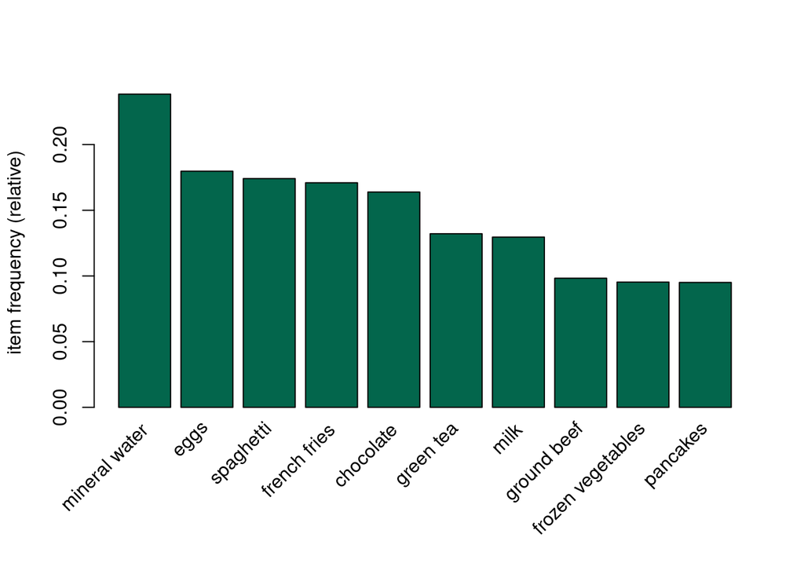

```r
# Displaying top 10 most common items in the transactions
# and the items whose relative importance is at least 8%
#
itemFrequencyPlot(transactions, topN = 10,col="#03664c")
```

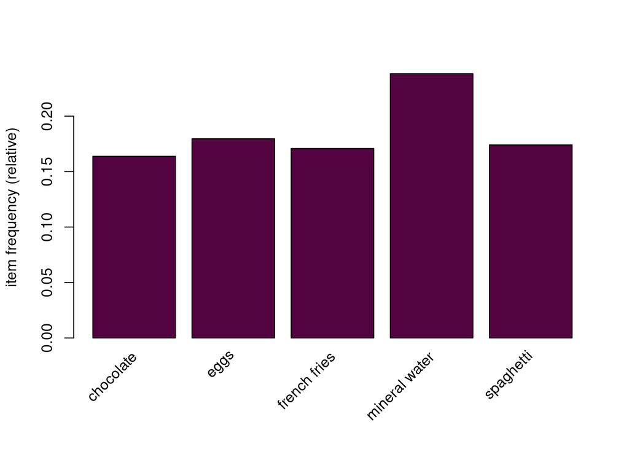

```r
itemFrequencyPlot(transactions, support = 0.15,col="#53033f")
```

Mineral water,eggs and spaghetti are the most frequent items. Mineral water,eggs,spaghetti,french fries and chocolates are the most Important items in the supermarket.

```r
# Min Support as 0.001 and confidence as 0.8
# absolute min support is floor( transactions/ supp)
# confidence and number of rules are inversely proportional.
# confidence seems to specify the minimum conficdence level of the rules
# e.g support at 0.5 and confidence at 0.9
# equals absolute min support count= 3750 and no rules
rule <- apriori (transactions, parameter = list(supp = 0.001, conf = 0.80))
```

```
Apriori

Parameter specification:
 confidence minval smax arem  aval originalSupport maxtime support minlen
        0.8    0.1    1 none FALSE            TRUE       5   0.001      1
 maxlen target  ext
     10  rules TRUE

Algorithmic control:
 filter tree heap memopt load sort verbose
    0.1 TRUE TRUE  FALSE TRUE    2    TRUE

Absolute minimum support count: 7

set item appearances ...[0 item(s)] done [0.00s].
set transactions ...[119 item(s), 7501 transaction(s)] done [0.00s].
sorting and recoding items ... [116 item(s)] done [0.00s].
creating transaction tree ... done [0.00s].
checking subsets of size 1 2 3 4 5 6 done [0.00s].
writing ... [74 rule(s)] done [0.00s].
creating S4 object  ... done [0.00s].
```

```r
rule
```

```
set of 74 rules
```

created 74 rules, for the dataset

```r
summary(rule)
```

```
set of 74 rules

rule length distribution (lhs + rhs):sizes
 3  4  5  6
15 42 16  1

   Min. 1st Qu.  Median    Mean 3rd Qu.    Max.
  3.000   4.000   4.000   4.041   4.000   6.000

summary of quality measures:
    support           confidence        coverage             lift
 Min.   :0.001067   Min.   :0.8000   Min.   :0.001067   Min.   : 3.356
 1st Qu.:0.001067   1st Qu.:0.8000   1st Qu.:0.001333   1st Qu.: 3.432
 Median :0.001133   Median :0.8333   Median :0.001333   Median : 3.795
 Mean   :0.001256   Mean   :0.8504   Mean   :0.001479   Mean   : 4.823
 3rd Qu.:0.001333   3rd Qu.:0.8889   3rd Qu.:0.001600   3rd Qu.: 4.877
 Max.   :0.002533   Max.   :1.0000   Max.   :0.002666   Max.   :12.722
     count
 Min.   : 8.000
 1st Qu.: 8.000
 Median : 8.500
 Mean   : 9.419
 3rd Qu.:10.000
 Max.   :19.000

mining info:
         data ntransactions support confidence
 transactions          7501   0.001        0.8
```

The rules range from having 3 to 6 items. only one rule has 6 items though Most rules have 4 items None have 2 items in the rules because it’s hard to predict what someone will buy just from just one item, there are a lot of combinations that could be made.

```r
# Observing the first 5 model rules
inspect(rule[1:5])
```

```
    lhs                             rhs             support     confidence
[1] {frozen smoothie,spinach}    => {mineral water} 0.001066524 0.8888889
[2] {bacon,pancakes}             => {spaghetti}     0.001733102 0.8125000
[3] {nonfat milk,turkey}         => {mineral water} 0.001199840 0.8181818
[4] {ground beef,nonfat milk}    => {mineral water} 0.001599787 0.8571429
[5] {mushroom cream sauce,pasta} => {escalope}      0.002532996 0.9500000
    coverage    lift      count
[1] 0.001199840  3.729058  8
[2] 0.002133049  4.666587 13
[3] 0.001466471  3.432428  9
[4] 0.001866418  3.595877 12
[5] 0.002666311 11.976387 19
```

```r
# sorting the rules using confidence levels
rules<-sort(rule, by="confidence", decreasing=TRUE)
inspect(rules[1:5])
```

```
    lhs                                          rhs             support
[1] {french fries,mushroom cream sauce,pasta} => {escalope}      0.001066524
[2] {ground beef,light cream,olive oil}       => {mineral water} 0.001199840
[3] {cake,meatballs,mineral water}            => {milk}          0.001066524
[4] {cake,olive oil,shrimp}                   => {mineral water} 0.001199840
[5] {mushroom cream sauce,pasta}              => {escalope}      0.002532996
    confidence coverage    lift      count
[1] 1.00       0.001066524 12.606723  8
[2] 1.00       0.001199840  4.195190  9
[3] 1.00       0.001066524  7.717078  8
[4] 1.00       0.001199840  4.195190  9
[5] 0.95       0.002666311 11.976387 19
```

There were some rules with 100% confidence: if a customer buys french fries,mushroom cream sauce and pasta they are 100% likely to buy escalope. Which is an improvment of the previous rule if someone buys mushroom cream sauce and pasta they are 95% likely to buy escalope

```r
# getting rules specific to buying chocolate
choco <- subset(rules, subset = rhs %pin% 'chocolate')
choco<-sort(choco, by="confidence", decreasing=TRUE)
inspect(choco)
```

```
    lhs                               rhs         support     confidence
[1] {escalope,french fries,shrimp} => {chocolate} 0.001066524 0.8888889
[2] {red wine,tomato sauce}        => {chocolate} 0.001066524 0.8000000
    coverage    lift     count
[1] 0.001199840 5.425188 8
[2] 0.001333156 4.882669 8
```

There were only 2 rules concerning buying chocolate above 80% confidence level. These were:

- Customers buying escalope,french fries and shrimp had 88.89% likelihood of buying chocolate
- Customers buying red wine and tomato sauce had a 80% likelihood of buying chocolate

THe model was able to create rules for customer transactions in the supermarket.